# Weathering and the Formation of Soil

Dr. Ahmad Redaa

2025-01-28

# Weathering and the Formation of Soil

## **What is Soil?**

- **Definition:**  
  Soil is the upper layer of Earth’s surface, composed of weathered minerals, organic matter, water, and air.
- **Importance:**
  - Vital for sustaining plant growth.
  - Provides nutrients and a medium for ecosystems.

## **Soil Components**

- **Minerals (~45%):** Clay minerals, quartz, feldspar, and rock fragments.
- **Organic Matter (~5%):** Decayed plant and animal material.
- **Air and Water (~50%):** Fill the empty spaces between particles.

# Soil texture

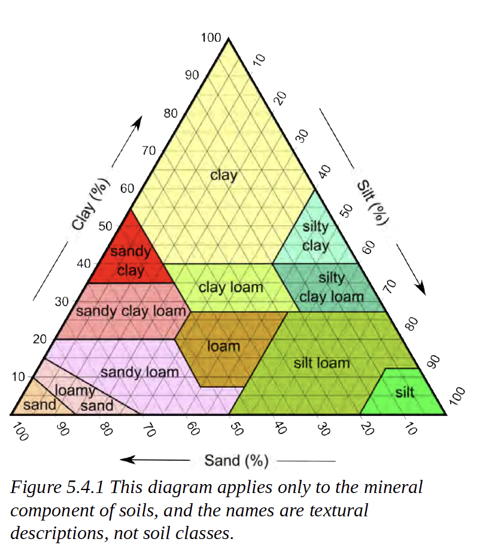

Source: [Steven, E. (2015)](https://openlibrary-repo.ecampusontario.ca/jspui/handle/123456789/402)

## **Factors Influencing Soil Formation**

1. **Climate:**
   - Warm and moderate precipitation climates favor soil development.
   - Tropical climates can lead to nutrient-leached acidic soils.
   - Arid climates cause the accumulation of salts and limited organic matter.
2. **Parent Material:**
   - Residual soil forms on bedrock.
   - Transported soil forms on unconsolidated material (e.g., river deposits).
   - Quartz-rich materials generate sandy soils; basaltic materials generate fertile soils.
3. **Slope/Topography:**
   - Steep slopes limit soil retention.
   - Soil formation occurs where erosion rates are low.
4. **Time:**
   - Soil takes thousands of years to develop.
   - Younger soils are found in recently glaciated or newly formed surfaces.
5. **Biological Activity**
   - Organisms contribute to weathering and organic matter accumulation, enhancing soil fertility.

## **Soil and Weathering**

- **Weathering’s Role in Soil Formation:**
  - Breaks down rocks into mineral particles and releases nutrients.
  - Mechanical weathering produces fragments, increasing surface area.
  - Chemical weathering transforms primary minerals into clays and dissolves ions.
- **Example:**
  - In warm climates, chemical weathering dominates, leading to clay-rich soils.

## **Types of Soil**

1. **Pedalfer Soil:**
   - Found in humid regions.
   - Rich in aluminum and iron oxides.
   - Supports forest ecosystems.
   - The term ” pedalfer ” is derived from the prefix “ped” (meaning soil) and “alfer” which refers to the presence of aluminum and iron oxides.
   - Typically reddish or yellowish due to iron oxides; the color can vary based on the specific mineral content and organic matter.
2. **Pedocal Soil:**
   - Found in dry regions (Arid and semi-arid regions).
   - Rich in calcium carbonate (Water begins to move down through the soil layers, but before it gets very far, it begins to evaporate. Soluble minerals, like calcium carbonate, concentrate in a layer that marks the lowest place that water was able to reach. This layer is called caliche)
   - Associated with grassland vegetation.
3. **Laterite Soil:**
   - Found in tropical regions (rainy every day).
   - Rich in iron and aluminum oxides.
   - Nutrient-poor due to leaching.

## **Soil Horizons**

- **Definition:**  
  Soil horizons are distinct layers within a soil profile that develop over time due to weathering, organic activity, and leaching.
- **Importance:**
  - Each horizon reflects specific soil-forming processes.
  - Understanding horizons is essential for agriculture, ecology, and environmental studies.

## **Soil Profile Overview**

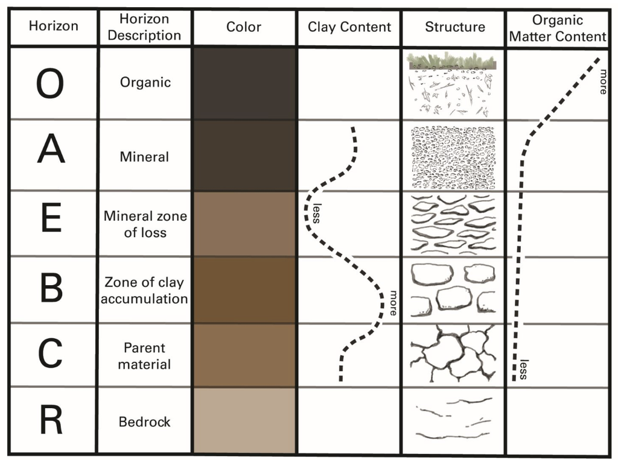

Source: [https://iastate.pressbooks.pub](https://iastate.pressbooks.pub/introsoilscience/chapter/soil-horizons/)

- Typical soil profile includes six horizons:
  1. **O Horizon**
  2. **A Horizon**
  3. **E Horizon**
  4. **B Horizon**
  5. **C Horizon**
  6. **R Horizon**

## **O Horizon: Organic Layer**

- **Definition:**  
  The uppermost layer composed of decomposed organic material such as leaves, twigs, and plant remains.
- **Features:**
  - Dark in color due to high organic content.
  - Supports microbial and biological activity.
  - Found in forested or vegetative regions.

## **A Horizon: Topsoil**

- **Definition:**  
  The mineral-rich layer mixed with organic matter, critical for plant growth.
- **Features:**
  - Dark to brown color.
  - Contains nutrients, water, and microorganisms.
  - Known as the **zone of leaching** where minerals and nutrients start to move downward.

## **E Horizon: Eluviation Layer**

- **Definition:**  
  A lighter-colored layer where leaching or eluviation removes minerals and organic matter.
- **Features:**
  - Lacks nutrients and organic material.
  - Rich in resistant minerals like quartz.
  - Found in acidic or well-drained soils.

## **B Horizon: Subsoil**

- **Definition:**  
  The layer where materials leached from above accumulate, also known as the **zone of accumulation.**
- **Features:**
  - Reddish or brown due to iron and clay deposits.
  - Denser than the upper layers.
  - Stores minerals like iron, aluminum, and silicates.

## **C Horizon: Parent Material**

- **Definition:**  
  A layer of partially weathered rock and minerals that serves as the source material for soil formation.
- **Features:**
  - No organic matter.
  - Larger rock fragments are present.
  - Reflects the composition of the parent rock.

## **R Horizon: Bedrock**

- **Definition:**  
  The solid, unweathered rock beneath all other soil layers.
- **Features:**
  - Hard and compact.
  - Provides the foundation for the soil profile.
  - Weathering processes begin here to create the C Horizon.

## **Soil Profile Summary**

[interactive chart not shown]